# Model Basics & Linear Regression

Dylan Maddux

2024-09-15

**S. Bradley and colleagues (2015) at Clarke University gave two identical surveys to a sample of n = 203 students (i.e., each student did the survey twice). Each survey contained 25 writing specimens, and the students were asked to identify whether the author self-identified as male or female. (Of the 25 specimens, 12 were written by a female author, and 13 were written by a male author.) Each specimen consisted of a handwritten address, such as might appear on an envelope, and gave no semantic clues to indicate the author’s gender.**

### Part 1

**Question 1** Import the data into your R session and save it as the object Handwriting. Briefly review the codebook. What does the Survey1 variable represent?

```r
library(dplyr)
library(ggplot2)
Handwriting <- read.csv('data/Handwriting.csv')
head(Handwriting)
```

```
##   Individual Gender Survey1 Survey2 FemaleID MaleID Both DIFF
## 1          1      1      72      68     75.0   69.2   68    4
## 2          2      0      56      68     41.7   69.2   48  -12
## 3          3      1      68      48     75.0   61.5   36   20
## 4          4      1      80      80     83.3   76.9   76    0
## 5          5      1      76      72     83.3   69.2   68    4
## 6          6      1      76      60     75.0   76.9   60   16
```

The Survey1 variable represents the percentage of correct guesses by each individual of the author’s gender in Survey 1.

**Question 2** Use the dplyr::glimpse function to review the data structure. Are there any character vectors in the data? Should any of the variables be considered as categorical variables?

```r
dplyr::glimpse(Handwriting)
```

```
## Rows: 204
## Columns: 8
## $ Individual <int> 1, 2, 3, 4, 5, 6, 7, 8, 9, 10, 11, 12, 13, 14, 15, 16, 17, …
## $ Gender     <int> 1, 0, 1, 1, 1, 1, 0, 0, 0, 1, 0, 1, 0, 0, 1, 0, 0, 1, 0, 1,…
## $ Survey1    <int> 72, 56, 68, 80, 76, 76, 60, 68, 52, 64, 64, 64, 64, 68, 60,…
## $ Survey2    <int> 68, 68, 48, 80, 72, 60, 60, 68, 48, 72, 72, 72, 56, 76, 72,…
## $ FemaleID   <dbl> 75.0, 41.7, 75.0, 83.3, 83.3, 75.0, 66.7, 75.0, 33.3, 75.0,…
## $ MaleID     <dbl> 69.2, 69.2, 61.5, 76.9, 69.2, 76.9, 53.8, 61.5, 69.2, 53.8,…
## $ Both       <int> 68, 48, 36, 76, 68, 60, 36, 64, 36, 64, 44, 64, 44, 60, 60,…
## $ DIFF       <int> 4, -12, 20, 0, 4, 16, 0, 0, 4, -8, -8, -8, 8, -8, -12, -16,…
```

There are no character vectors in the data, and gender and individual ID should be considered categorical variables.

**Question 3** Make a histogram of the variable Survey1. Briefly discuss what the histogram suggests about the percentage correct on the first survey.

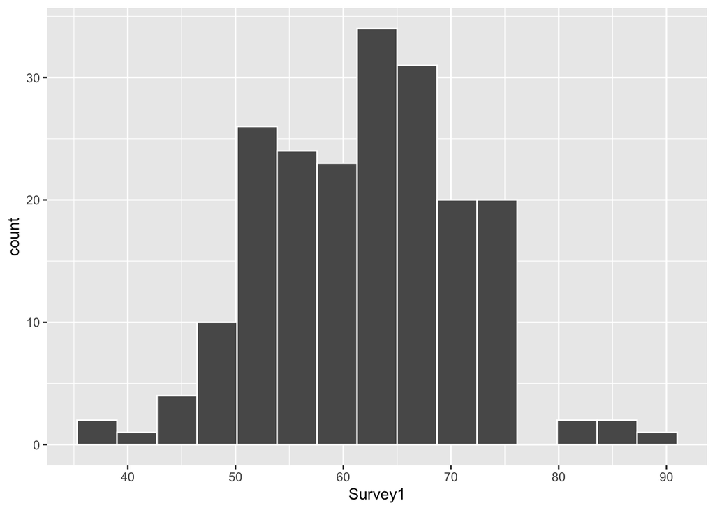

```r
ggplot(Handwriting, aes(x=Survey1)) +
  geom_histogram(bins = 15, color = "white")
```

The histogram suggests that the distribution of people’s accuracy levels at guessing the author’s gender ranged on average from around 50% to 75%.

**Question 4** Do you think that the subjects were better at guessing the author’s gender on the first survey, compared to random guessing (e.g., by flipping a coin and guessing female if heads and male if tails)? Write out a model that describes this situation, and then write null and alternative hypotheses for testing whether the subjects did better than random guessing.

Yes, I think the subjects were better at guessing the author’s gender on the first survey compared to random guessing.

y = μ + ϵ

H0: μ = 50

Ha: μ > 50

**Question 5** Compute summary statistics for the Survey1 variable, and use them to construct the fitted model.

```r
summary(Handwriting$Survey1)
```

```
##    Min. 1st Qu.  Median    Mean 3rd Qu.    Max.    NA's
##   36.00   56.00   64.00   62.52   68.00   88.00       4
```

ŷ = 62.52 + ϵ

**Question 6** Suppose that the first survey was administered to a new student. Based on the fitted model, what is the predicted percentage of specimens that this student would identify correctly?

Based on the fitted model, the predicted percentage of specimens that this student would identify correctly is 62.5%.

**Question 7** Add a column to your Handwriting data frame, consisting of the model residuals.

```r
Handwriting <- Handwriting %>%
  mutate(Residuals = Survey1 - 62.5)
```

**Question 8** Modify the code you used above to make a histogram of the residuals. Comment on whether the graph supports the idea that the residuals are normally distributed.

[figure not shown]

```r
ggplot(Handwriting, aes(x=Residuals)) +
  geom_histogram(bins = 15, color = "white")
```

The graph supports the idea that the residuals are normally distributed.

**Question 9** Perform a one-sample t-test to assess the claim that the subjects are more successful than random guessing in identifying the author’s gender on the first survey. Give the values of the t-statistic and the p-value for this test.

```r
t.test(Handwriting$Survey1, alternative = "greater", mu = 50, paired = FALSE, var.equal = FALSE, conf.level = 0.95)
```

```
##
##  One Sample t-test
##
## data:  Handwriting$Survey1
## t = 18.587, df = 199, p-value < 2.2e-16
## alternative hypothesis: true mean is greater than 50
## 95 percent confidence interval:
##  61.40687      Inf
## sample estimates:
## mean of x
##     62.52
```

t = 18.587, p = 2.2e-16

**Question 10** Give conclusions in context for this test, stated for (a) a statistical audience and (b) a non-statistical audience.

1. The extremely low p-value (far under <.05) and mean of 62.52% indicates that the percentage of correct answers in Survey 1 significantly exceeds 50%.
2. Surveyed individuals were correct at a higher rate than the odds of random guessing.

**Question 11** Do you think female respondents were more effective than male respondents at correctly identifying female authors on the first survey? Write a model that describes this situation, along with corresponding null and alternative hypotheses.

Yes, I think female respondents were more effective than male respondents at correctly identifying female authors on the first survey.

model: y = μi + ϵ

μ1 = male responses correct average, μ2 = female responses correct average

H0: μ1 = μ2

Ha: μ1 < μ2

### Part 2

**Question 1** Because we’re now interested in the possibility of differential effects by gender in the ability to identify specifically female authors, the Survey1 variable is no longer the appropriate response variable. What response variable should you use instead?

The response variable we should now use instead is the FemaleID variable.

**Question 2** Construct an appropriate graph to visualize the differences between the guessing abilities between female and male students, as measured by your response variable, and briefly discuss what the graph suggests regarding the hypothesis of differential guessing abilities by gender. Then write out an appropriate statistical model that describes this situation.

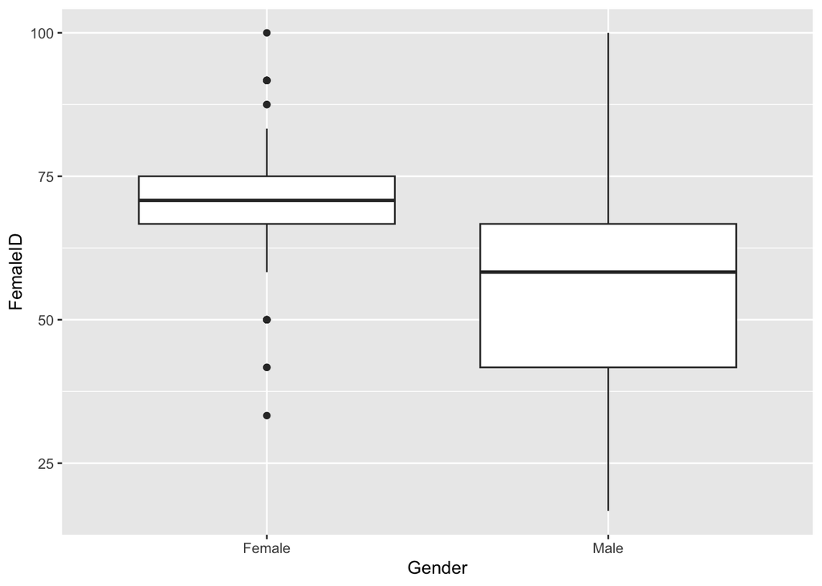

```r
library(ggplot2)
library(dplyr)
library(stringr)
Handwriting <- Handwriting %>%
  mutate(Gender = str_replace(Gender, "0", "Male")) %>%
  mutate(Gender = str_replace(Gender, "1", "Female")) %>%
  filter(!row_number() %in% c(204))

ggplot(data = Handwriting, aes(x=Gender, y=FemaleID)) +
         geom_boxplot()
```

The graph suggests that female participants were better than male participants at identifying female authors.

y = μi + ϵ

μmale < μfemale

**Question 3** Estimate the model appropriately from the data, and report the fitted model.

```r
summary(lm(FemaleID ~ Gender, data = Handwriting))
```

```
##
## Call:
## lm(formula = FemaleID ~ Gender, data = Handwriting)
##
## Residuals:
##     Min      1Q  Median      3Q     Max
## -38.932  -5.632   2.668   6.868  44.368
##
## Coefficients:
##             Estimate Std. Error t value Pr(>|t|)
## (Intercept)   70.616      1.339  52.734  < 2e-16 ***
## GenderMale   -14.984      2.000  -7.492 2.11e-12 ***
## ---
## Signif. codes:  0 '***' 0.001 '**' 0.01 '*' 0.05 '.' 0.1 ' ' 1
##
## Residual standard error: 14.17 on 201 degrees of freedom
## Multiple R-squared:  0.2183, Adjusted R-squared:  0.2144
## F-statistic: 56.13 on 1 and 201 DF,  p-value: 2.109e-12
```

y = -14.98x + 70.62

x: 1 = Male, 0 = Female

**Question 4** Construct an appropriate plot of the residuals from your model, and comment on whether the plot supports the idea that the residuals are normally distributed. Carry out the appropriate test to assess the difference between female and male students in identifying female authors on the first survey, and report your hypotheses, test statistic, and p-value. Construct an appropriate confidence interval to quantify the apparent magnitude of the difference in success rates between female and male respondents in identifying female authors.

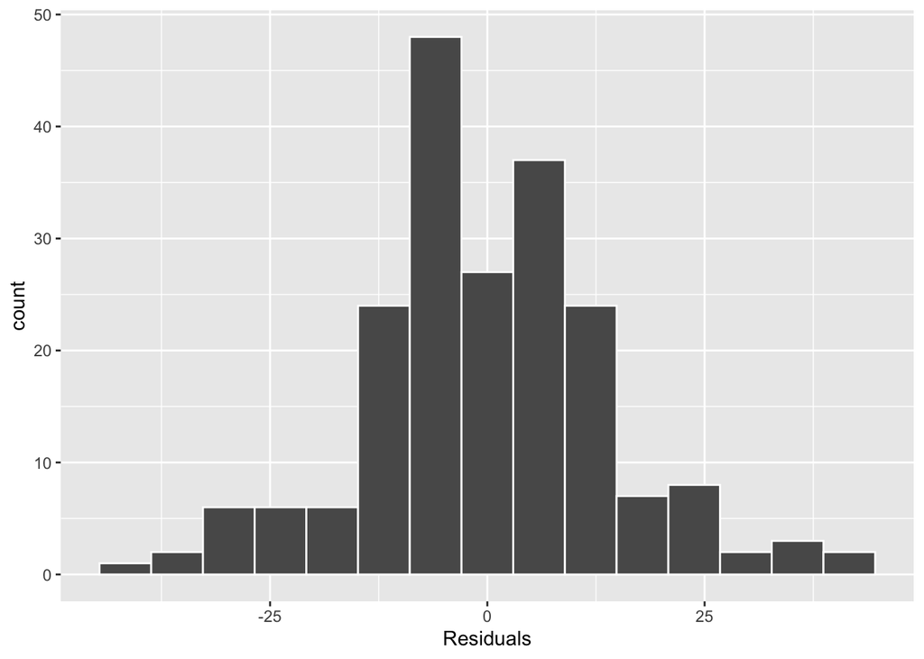

```r
Handwriting1 <- Handwriting %>%
  mutate(Residuals = ifelse(Gender == "Male", FemaleID - 55.63, ifelse(Gender == "Female", FemaleID - 70.62, 0)))

ggplot(Handwriting1, aes(x=Residuals)) +
  geom_histogram(bins = 15, color = "white")
```

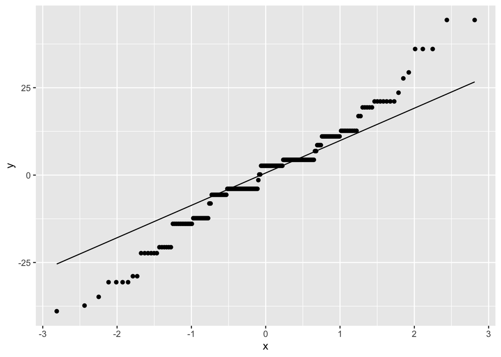

```r
ggplot(data = Handwriting1, aes(sample = Residuals)) +
  geom_qq() + geom_qq_line()
```

```r
mcorrect <- subset(Handwriting, subset = Gender == "Male")
fcorrect <- subset(Handwriting, subset = Gender == "Female")

t.test(mcorrect$FemaleID, fcorrect$FemaleID)
```

```
##
##  Welch Two Sample t-test
##
## data:  mcorrect$FemaleID and fcorrect$FemaleID
## t = -7.2262, df = 155.31, p-value = 2.101e-11
## alternative hypothesis: true difference in means is not equal to 0
## 95 percent confidence interval:
##  -19.0803 -10.8881
## sample estimates:
## mean of x mean of y
##  55.63187  70.61607
```

The plot does not support the idea that the residuals are normally distributed as it displays a long-tailed residual distribution.

H0: μmale_score = μfemale_score

Ha: μmale_score ≠ μfemale_score

t-test: -7.2262, p-value: 2.101e-11

Confidence Interval for Difference: [-19.08, -10.89]

**Question 5** Carefully state your conclusion regarding the research question of interest, including any limitations or reservations you think are warranted based on the model or the data.

The p-value of 2.101e-11 and difference in means of an average of 15 percentage points suggests that female participants were better than male participants at identifying female authors. However, the lack of explanatory variables beside Gender makes it difficult to draw definitive conclusions from the model.

**Question 6** Do we observe similar results for male authors? In other words, is there any difference between male and female respondents in terms of identifying male authors on the first survey? Repeat the steps above for the relevant response variable, and report your results at each step.

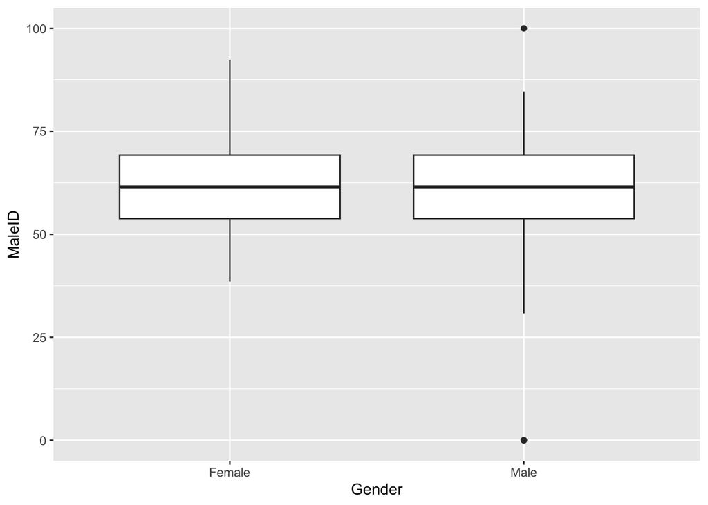

```r
ggplot(data = Handwriting, aes(x=Gender, y=MaleID)) +
         geom_boxplot()
```

The graph suggests that male and female participants were equally accurate at identifying male authors.

y = μi + ϵ

μmale = μfemale

```r
summary(lm(MaleID ~ Gender, data = Handwriting))
```

```
##
## Call:
## lm(formula = MaleID ~ Gender, data = Handwriting)
##
## Residuals:
##     Min      1Q  Median      3Q     Max
## -60.126  -8.128  -0.428   9.074  39.874
##
## Coefficients:
##             Estimate Std. Error t value Pr(>|t|)
## (Intercept)   61.928      1.253  49.430   <2e-16 ***
## GenderMale    -1.801      1.871  -0.963    0.337
## ---
## Signif. codes:  0 '***' 0.001 '**' 0.01 '*' 0.05 '.' 0.1 ' ' 1
##
## Residual standard error: 13.26 on 201 degrees of freedom
## Multiple R-squared:  0.004589,   Adjusted R-squared:  -0.000363
## F-statistic: 0.9267 on 1 and 201 DF,  p-value: 0.3369
```

y = -1.801x + 61.928

x: 1 = Male, 0 = Female

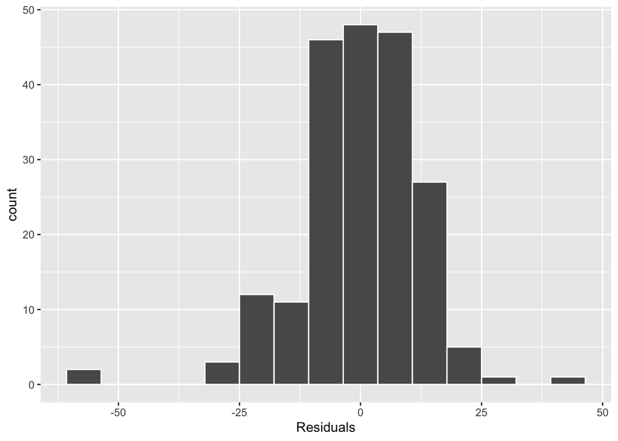

```r
Handwriting2 <- Handwriting %>%
  mutate(Residuals = ifelse(Gender == "Male", MaleID - 60.13, ifelse(Gender == "Female", MaleID - 61.93, 0)))

ggplot(Handwriting2, aes(x=Residuals)) +
  geom_histogram(bins = 15, color = "white")
```

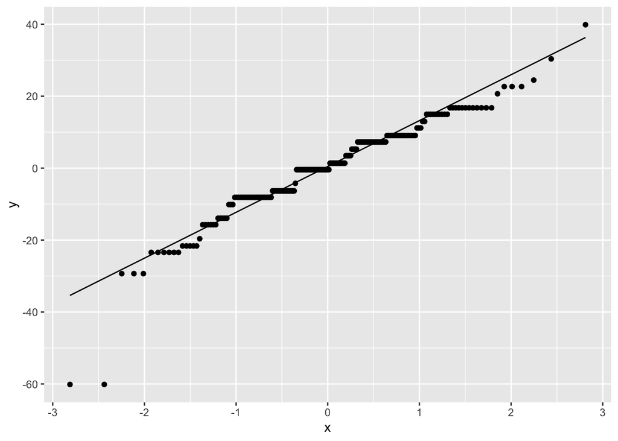

```r
ggplot(data = Handwriting2, aes(sample = Residuals)) +
  geom_qq() + geom_qq_line()
```

```r
t.test(mcorrect$MaleID, fcorrect$MaleID)
```

```
##
##  Welch Two Sample t-test
##
## data:  mcorrect$MaleID and fcorrect$MaleID
## t = -0.92805, df = 154.73, p-value = 0.3548
## alternative hypothesis: true difference in means is not equal to 0
## 95 percent confidence interval:
##  -5.635513  2.032903
## sample estimates:
## mean of x mean of y
##  60.12637  61.92768
```

The plot generally supports the idea that the residuals are normally distributed, although there are a few outliers that fall on the extreme ranges of the residuals.

H0: μmale_score = μfemale_score

Ha: μmale_score ≠ μfemale_score

t-test: -.928, p-value: 0.3548

Confidence Interval for Difference: -5.64 to 2.03

### Part 3

**Question 1** Our fundamental question here is whether we can predict success in identifying the gender of the author on Survey 2 using the success rate from Survey 1. In other words, if we know a respondent’s success rate from the first survey, does it predict their success rate on the second survey? Make an appropriate graph to visualize this relationship, and then write out a simple linear regression model to describe the relationship.

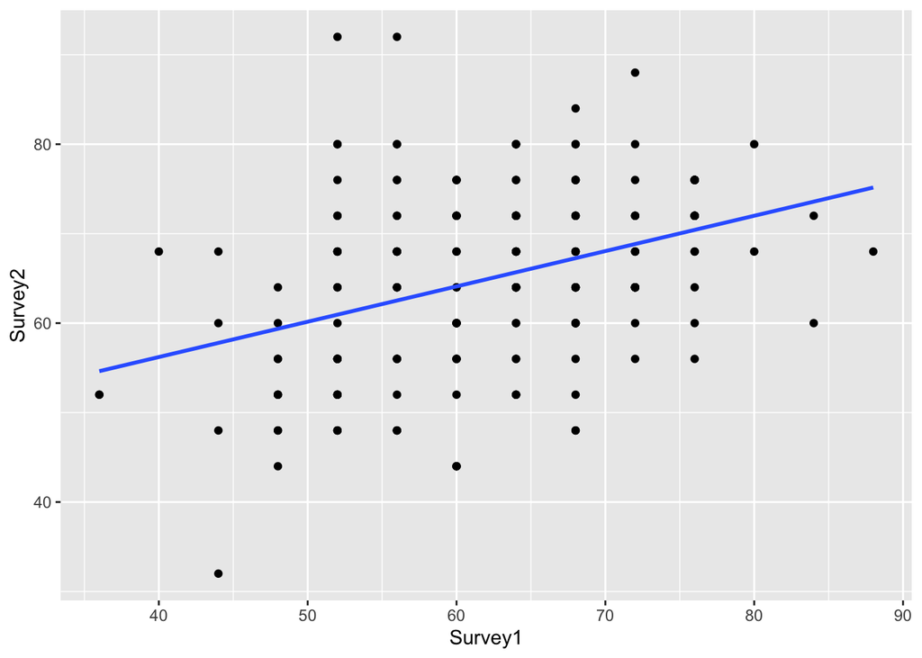

```r
Handwriting <- read.csv("data/Handwriting.csv")
library(ggplot2)

ggplot(Handwriting, aes(x=Survey1, y=Survey2)) +
  geom_point() +
  geom_smooth(method = "lm", se=F)
```

Survey2 = β0 + β1Survey1 + ϵ

**Question 2** If there is no relationship between success on the first survey and success on the second survey, what would you expect the slope of the line to be? What would this value say about whether identifying the author’s gender is an actual skill? If there is some relationship, what sorts of values would you expect to see for the slope parameter? Lastly, if success on survey 2 could be reliably predicted by success on survey 1, what would you expect the slope of the line to be?

1. If there is no relationship between success on the first and second survey, the slope of the line would be near 0 as it would be expected to be random. This would indicate a low likelihood that identifying the author’s gender is an actual skill since people’s scores would have fluctuated.
2. If there is some sort of relationship, I would expect the slope to be between [1,0) or (0,1]: a higher score on the 2nd survey than the 1st is predicted.
3. If success on survey 2 could be reliably predicted by success on survey 1, I’d expect the slope of the line to be between (0,1].

**Question 3** Fit the simple linear regression model. Write the fitted equation of the line, and add the fitted line to your plot from #1 above.

```r
model <- lm(Survey2~Survey1, Handwriting)
summary(model)
```

```
##
## Call:
## lm(formula = Survey2 ~ Survey1, data = Handwriting)
##
## Residuals:
##      Min       1Q   Median       3Q      Max
## -25.7870  -6.4722   0.6339   5.9487  31.0547
##
## Coefficients:
##             Estimate Std. Error t value Pr(>|t|)
## (Intercept) 40.41661    4.43100   9.121  < 2e-16 ***
## Survey1      0.39478    0.07004   5.637 6.07e-08 ***
## ---
## Signif. codes:  0 '***' 0.001 '**' 0.01 '*' 0.05 '.' 0.1 ' ' 1
##
## Residual standard error: 9.338 on 193 degrees of freedom
##   (9 observations deleted due to missingness)
## Multiple R-squared:  0.1414, Adjusted R-squared:  0.1369
## F-statistic: 31.77 on 1 and 193 DF,  p-value: 6.074e-08
```

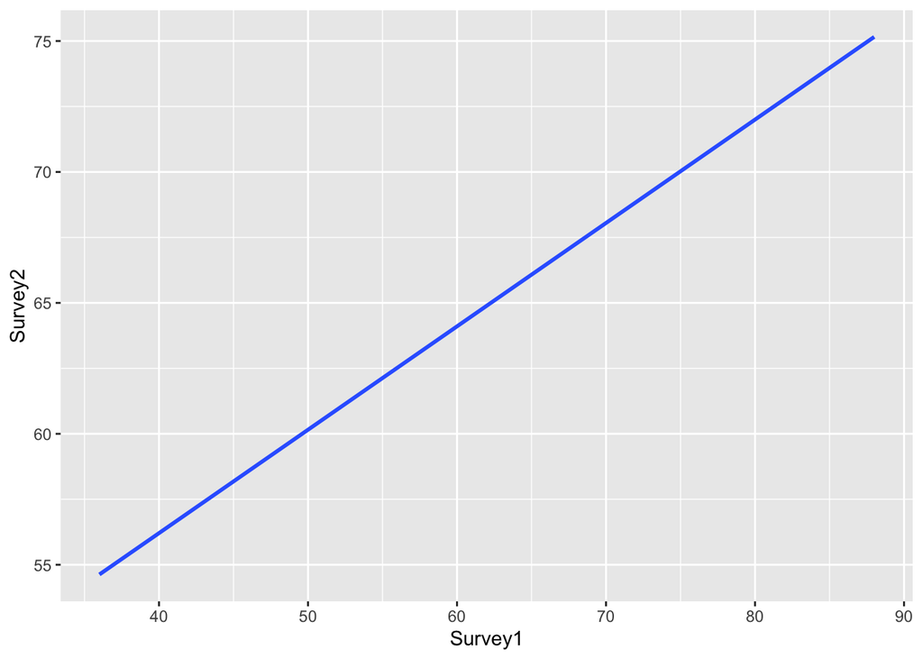

```r
ggplot(Handwriting, aes(x=Survey1, y=Survey2)) +
  geom_smooth(method = "lm", se=F)
```

y = .39x + 40.42

y = Survey2 score, x = Survey1 score

**Question 4** Construct appropriate residual plots, and comment on whether the data appear to meet the conditions for inference with this model. Assess the model, using the plots and other appropriate information. Is this a “good” model for the relationship of interest? What indications can you use to judge whether it’s a good model?

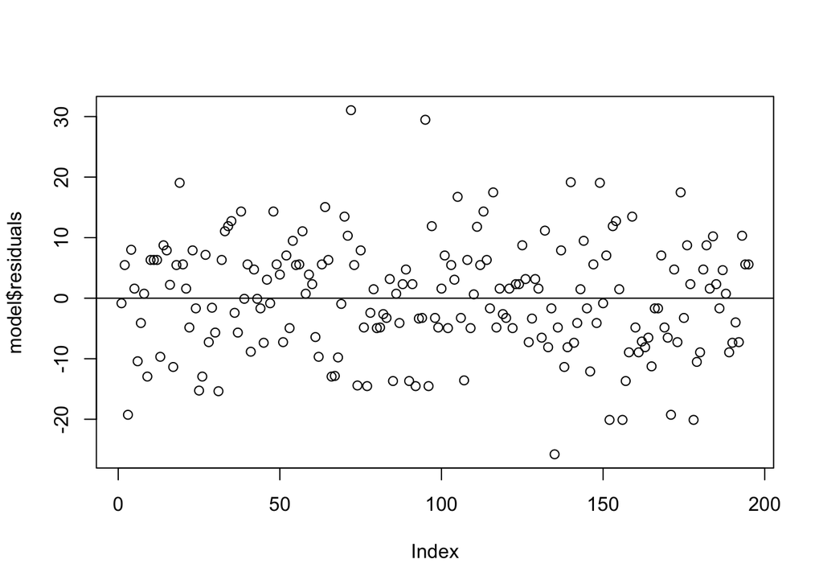

```r
res <- resid(model)

plot(model$residuals)
abline(0,0)
```

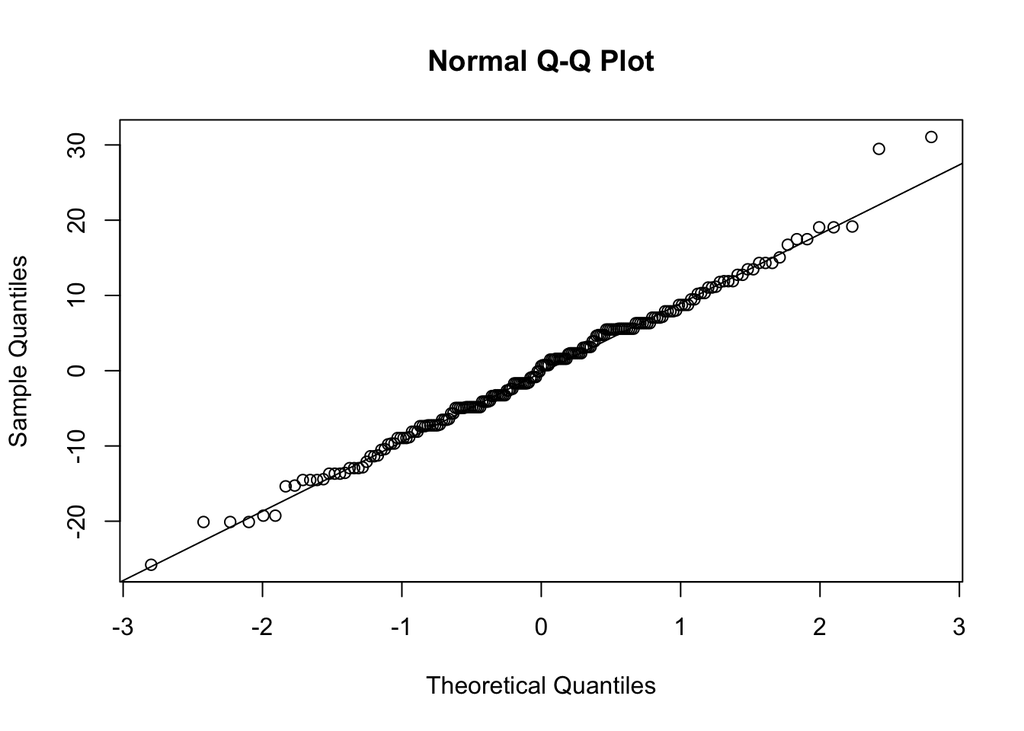

```r
qqnorm(res)
qqline(res)
```

```r
summary(model)
```

```
##
## Call:
## lm(formula = Survey2 ~ Survey1, data = Handwriting)
##
## Residuals:
##      Min       1Q   Median       3Q      Max
## -25.7870  -6.4722   0.6339   5.9487  31.0547
##
## Coefficients:
##             Estimate Std. Error t value Pr(>|t|)
## (Intercept) 40.41661    4.43100   9.121  < 2e-16 ***
## Survey1      0.39478    0.07004   5.637 6.07e-08 ***
## ---
## Signif. codes:  0 '***' 0.001 '**' 0.01 '*' 0.05 '.' 0.1 ' ' 1
##
## Residual standard error: 9.338 on 193 degrees of freedom
##   (9 observations deleted due to missingness)
## Multiple R-squared:  0.1414, Adjusted R-squared:  0.1369
## F-statistic: 31.77 on 1 and 193 DF,  p-value: 6.074e-08
```

The plot appears to be normally distributed, the variance of the errors is homoscedastic, and the errors are independent.

**Question 5** State your conclusion about whether we can effectively predict success rate on the second survey using success rate from the first survey, in light of your discussion in #4 above.